# Satellite Data and Google Trends

Inter-American Development Bank Workshop

Diego A. Guerrero

2025-11-23

# Learning Objectives

- Apply basic download and analysis to satellite imagery and Google search trends.
- Perform data cleaning using standard economic adjustments: deflation, seasonal adjustment, and growth rates.
- Estimate a simple Ordinary Least Square model to macroeconomic data

# Satellite Data

## Nighttime Lights

Nighttime satellite imagery provides a valuable proxy for **economic activity**, **electrification**, and **urban growth**.

It measures the **intensity of light emissions** in radiance (watt per steradian per square metre): a measure of radiant flux on a surface.

Data is available at **fine spatial and temporal resolutions**.

## Why It’s Complex

Working with satellite data (NASA’s **Nighttime Lights (VIIRS)** data) involves multiple steps, large files, and conversions from unstructured formats.

- It is the most complex code blocks in the workflow: **geospatial processing**, **data scraping**, and **time-series construction**.

## Workflow Overview

1. **Identify target locations**
   - Define the geographic boundaries.
   - Create a shapefile or bounding box for the selected areas.
2. **Download raw `.h5` map files**
   - Retrieve satellite imagery files directly from NASA’s repository.
   - Often requires authentication and automated scraping (via `requests` or NASA’s API).
   - Each file corresponds to a specific day/month.

## Workflow Overview (continued)

3. **Open and read the `.h5` files**
   - Use libraries like `h5py` `gdal` to extract pixel values.
   - Convert the raster data into usable arrays or DataFrames.
   - Aggregate data over the selected geographic units (e.g., county or grid cell).
4. **Clean and prepare the series**
   - Handle missing pixels and noise (cloud cover, stray light, etc.).
   - Average or sum pixel intensities to build a monthly or yearly time series.
   - Save a tidy dataset ready for merging with socioeconomic indicators.

## Shortcut – blackmarblepy

Install these dependencies:

```bash
pip install blackmarblepy
conda install folium geopandas mapclassify colorcet cmasher contextile branca --yes
```

## Exploring the map

```python
from blackmarble import BlackMarble, Product
from datetime import date
import geopandas as gpd
# or: "https://geodata.ucdavis.edu/gadm/gadm4.1/shp/gadm41_BHS_shp.zip"
shape = "session_2_files/gadm41_BHS_shp.zip"

gdf = gpd.read_file(shape)
g = gdf.explore(tiles="CartoDB dark_matter", zoom=7)
g
```

Make this Notebook Trusted to load map: File -> Trust Notebook

[interactive chart not shown]

## Load and plot nighttime lights

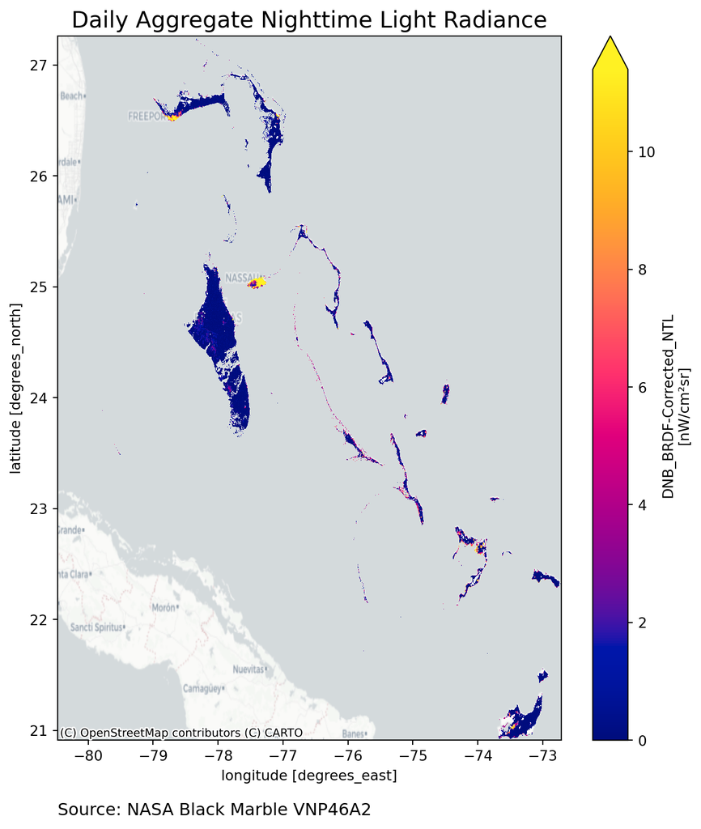

```python
token = "eyJ0eXAiOiJKV1QiLCJvcmlnaW4iOiJFYXJ0aGRhdGEgTG9naW4iLCJzaWciOiJlZGxqd3RwdWJrZXlfb3BzIiwiYWxnIjoiUlMyNTYifQ.eyJ0eXBlIjoiVXNlciIsInVpZCI6ImRndWVycmVybyIsImV4cCI6MTc2Njc3….Et-OQ4nkVw5Q-T7iiCDdTPbTq-kdzmEEcc_XF40-nI8DjsxvYeboLcGXbn3_6Hvd4_WOGR4Cmk6mUOv5TJ7P6MFNcIxXYE89W0h6tAHyB__KpCirG1QRdUKzxifwLP8GB_rvG_9Ag4VRe4Cd3mb6pS2REDNhUvkGbUcgOTiSNAJFVMKSVyB6mogVR1c42gV4Pg50OSr4Nb9sGZvEZm900LhbQS2nE0_jwwDn43QMmN7DG6JOQR5ciX0SYsX95ItfsAL0TmgMLsPadn6MPqkvxlk6VVdfHidhaA3DAf1BeZKhNzyeZzYlbIFZT-o1swZRlRffx_C5-T60PlcIzXjtfA"

bm = BlackMarble(token=token)
VNP46A2 = bm.raster(
    gdf,
    product_id="VNP46A2",
    date_range="2024-03-21",
)

import matplotlib.pyplot as plt
import contextily as cx
import cmasher as cm
import colorcet as cc

fig, ax = plt.subplots(figsize=(8, 9))

VNP46A2["DNB_BRDF-Corrected_NTL"].sel(time="2024-03-21").plot.pcolormesh(
    ax=ax,
    cmap=cc.cm.bmy,
    robust=True,
)

ax.set_title(
    "Daily Aggregate Nighttime Light Radiance",
    fontsize=16,
)
ax.text(
    0,
    -0.1,
    "Source: NASA Black Marble VNP46A2",
    ha="left",
    va="center",
    transform=ax.transAxes,
    fontsize=12,
    color="black",
    weight="normal",
)
cx.add_basemap(ax, source=cx.providers.CartoDB.Positron, crs=gdf.crs.to_string())
```

## NTL: Time series

[figure not shown]

```python
import pandas as pd

r_daily = bm.raster(
    gdf,
    product_id="VNP46A2",
    date_range=pd.date_range("2025-09-01", "2025-11-10", freq="D"),
)

# Create the figure and axis
fig, ax = plt.subplots(figsize=(10, 5))

# Plot NTL radiance
r_daily["DNB_BRDF-Corrected_NTL"].sum(dim=["x", "y"]).plot(ax=ax)

ax.set_title(
    "Daily Aggregate Nighttime Light Radiance", fontsize=18, weight="bold"
)
ax.set_xlabel("Date", fontsize=12)
ax.set_ylabel("Radiance (nW/cm²/sr)", fontsize=12)
plt.ylim(bottom=0)
ax.text(
    0,
    -0.2,
    "Source: NASA Black Marble VNP46A2",
    ha="left",
    va="center",
    transform=ax.transAxes,
    fontsize=10,
    color="black",
    weight="normal",
)

fig.tight_layout()
plt.show()
```

## A complete program

Two main parts:

- Downloading h5 files
- Rasterizing into a time series

## Downloading: Restrict download

Alternatively, visit https://ladsweb.modaps.eosdis.nasa.gov/ and download manually

```python
try :
    data = pd.read_csv(f"{path_source}/ntl_bahamas.csv", parse_dates=True)
    last_date = pd.to_datetime(data.groupby('location')['JD'].max().reset_index().JD.min())
    print("Last date in the directory:", last_date)
    last_date = last_date.strftime("%Y%j")
    last_year, last_day = last_date[:4], last_date[4:]
    print("In Julian Days:", last_date)
except :
    #Get last file in the directory
    PATH_NL_file_list = glob.glob(os.path.join(PATH_NL, '*.h5'))

    last_file = '.A2001001.'

    if PATH_NL_file_list:
        for file in PATH_NL_file_list :
            match = re.search(r'\.A(\d{4})(\d{3})\.', file)
            if match:
                year = match.group(1)
                julian_date = match.group(2)

                # Format the year and Julian date as '2012/019'
                start_year_day = f"{year}/{julian_date}"

                if int(start_year_day.replace("/","")) > int( re.search(r'\.A(\d{7})\.', last_file).group(1) ) :
                    last_file = file
                # You can save this formatted date as a variable for later use
                # formatted_date = f"{year}/{julian_date}"
            else:
                print("No Julian date and year found in the filename.")
        print("Last file in the directory:", last_file)
    else:
        print("The directory is empty.")

    match = re.search(r'\.A(\d{4})(\d{3})\.', last_file)
    last_year, last_day = match.group(1), match.group(2)


print(f"Last NTL collected: {last_year, last_day}")
```

## Download Functions

Three functions help with downloading:

```python
def download_vnp46a2(year, day_of_year, tile, output_dir=PATH_NL, file_list = available_files):
    """
    Download VNP46A2 file for specific date and tile
    Args:
        year: Year (e.g., 2023)
        day_of_year: Day of year (1-365/366)
        tile: Tile identifier (e.g., "h08v05")
        output_dir: Directory to save files
    """
    pass

def list_years(last_year, last_day, tile, output_dir=PATH_NL, collection="5200", product='VNP46A2'):
    # Find all available years
    # Get all available years
    # Keep only years >= last_year
    pass
    return years_to_download

def get_target(target, last_year, last_day, tile=the_tiles[0], output_dir=PATH_NL, collection="5200", product='VNP46A2'):
    """
    Download all available days from target years that are after last observation

    Args:
        target: List of years to check (e.g., ['2024', '2025'])
        last_year: Last year you have (e.g., 2024)
        last_day: Last day of year you have (e.g., 100)
        tile: Tile identifier
        output_dir: Output directory
    """
    pass
    return my_list
```

## Download required files

See https://ladsweb.modaps.eosdis.nasa.gov/archive/allData/5200/VNP46A2

```python
the_tiles = list(set(['h10v06']))
target = []
for tile in the_tiles :
    tile_target = list_years(last_year, last_day, tile )
    tile_target = get_target(tile_target , last_year, last_day, tile )
    target.append( [ (tile ,) + t for t in tile_target ] )
target = [x for sublist in target for x in sublist]

print(f"Last date available: {target[-1]}")
print("Downloading...")

for t in tqdm( target , desc="Processing") :
    download_vnp46a2( t[1] , t[2], t[0])

rasterFiles = [ x for x in rasterFiles if "VNP46A2" in x ]
rasterFiles.sort()
totalFiles = len(rasterFiles)
print("Finalized")
```

## Reading h5 files

- NASA’s Black Marble (VNP46A2/VNP46A3) is distributed as HDF5 (.h5) files.
- .h5 is efficient for storing multidimensional scientific arrays, but:
- Not directly readable by common GIS tools.
- Harder to visualize or tile for mapping.
- Requires custom code to extract specific layers.
- GeoTIFF (.tif) is the standard geospatial raster format.

## Helper Function

```bash
def conJDtoDate(JD):
    date = datetime.strptime(JD, '%y%j').date()
    return date

def getRasterData(lat, lon, window, xOrigin, yOrigin, pixelWidth, pixelHeight, data):
    pass
    return value


def processHD5(inputHD5, layer, OutputFolder, coords, Date ):
    pass
    return _datalist_
```

## Looping through h5 files

```python
records = data.groupby('location')['JD'].agg(list).to_dict()

mydata = []

for NOF in tqdm(range(0, totalFiles), desc="Processing") :
    _definelist_ = []
     # Get date
    dateOfYear = conJDtoDate(rasterNew[NOF][11:16])

    target = [
        point for point in locations_df.to_dict(orient='records')
        if
        ( pd.isnull(point['JD']) or pd.to_datetime(dateOfYear) not in records[point['location']] )
        and rasterFiles[0].split(".")[2] in the_tiles
    ]

    if len(target) == 0 : continue

    _toappend_ = processHD5(rasterFiles[NOF], 2, outputFolder, target, dateOfYear )

    [ mydata.append(f) for f in _toappend_ ]

for T in os.listdir(outputFolder) :
    if ".tif" in T : os.remove(f"{outputFolder}/{T}")
```

# Google Trends Data

## The Data

- Google Trends provides an index of search interest for keywords over time.
  - Nowcasting macroeconomic indicators
  - Measuring public attention (inflation, unemployment, policy events)
- Data features:
  - **Normalized** (0–100)
  - **Relative**, not absolute search volume
  - Available at daily, weekly, or monthly frequencies

## GTrends API

- Google **does not publish** a public API for Trends.
- They restrict access to:
  - Prevent abuse and large-scale scraping
  - Protect proprietary ranking algorithms
  - Reduce server load
- Unofficial API
  - `pytrends` and `gtrendsR` are traditional alternatives
  - In recent years Google has been sabotaging.

## Manual download

Right now, the best approach is to manually download csv files from

trends.google.com

## Trends Example

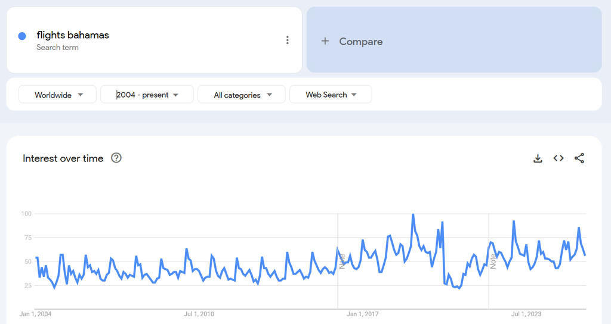

## Python: An organizing tool

While python can’t download the files, it can help organize multiple files.

```python
d = os.getcwd()+"/"
PATH_RAW = f"{d}/../source"
PATH_FORMAT = f"{d}/../data"
folder_spec = PATH_RAW


csv_files = glob.glob(os.path.join(PATH_RAW, "*multi*.csv"))
if len(csv_files)>0:
    df0 = pd.DataFrame()
    for csv in csv_files :
        dfi = pd.read_csv(csv, skiprows=1)
        dfi.rename(columns = {"Month" : 'date'}, inplace=True)
        dfi.date = pd.to_datetime(dfi['date'])
        dfi.columns = dfi.columns.astype(str).str.lower().str.strip()
        dfi.columns = [re.sub(r'\W+', '_', col).strip('_') for col in dfi.columns]
        dfi.set_index('date', inplace=True)

        df0 = pd.concat( [ df0, dfi], axis=1)
    df0.columns = ["gt_" + col for col in df0.columns]

    df0.to_csv(f'{PATH_RAW}/gtrends.csv')
    print(f'Last updated: {df0.index.max()}')

    for file in csv_files :
        os.remove(file)
```

# Activity

- Open `notebook_2.ipynb`
- Merge Bahamas GDP, Nighttime Lights, and Google Trends data in one DataFrame.
- Clean and resample all data as needed to the same frequency (quarterly)
- Estimate GDP using OLS